# Table of Contents

## Testing for Consistency

```python
import numpy as np
import os
# os.chdir('/home/medfad/Desktop/WD/Abdul/2019/Project_Euclid/CyPy')
from random import normalvariate, seed
from math import sqrt
from mymodule2 import dist
import sys
import timeit
from functions import *
```

```python
seed(1)
m, n = 1000, 2
M = np.empty([m,n])

for i in range(m):
    for j in range(n):
        M[i, j] = normalvariate(10, 10)
```

```python
M[:11, ]
```

```
array([[16.07455858,  9.85774554],
       [22.30907229, 20.15481167],
       [ 6.63543072, 22.17481809],
       [ 1.58685673,  7.88658975],
       [ 4.04653337,  1.07250122],
       [23.05670242, 12.99854821],
       [ 0.25372232, 23.15622659],
       [22.95613455, 27.17303476],
       [ 1.8207828 , 10.22054965],
       [-0.54504182, 18.71124194],
       [-2.43269821, 20.70067292]])
```

```python
d1 = dist(M)
d2 = the_loop(M, e_dist)
d3 = the_loop(M, dot_prod_dist)
```

```python
print("d1[:11]: ", d1[:11], "\n\n", "d2[:11]: ", d2[:11], "\n\n", "d3[:11]: ", d3[:11])
```

```
d1[:11]:  [12.03738892 15.51797057 14.62118189 14.8947611   7.65604167 20.66757019
 18.63264148 14.25839229 18.83070672 21.44965332  9.93768337]

 d2[:11]:  [12.03738892 15.51797057 14.62118189 14.8947611   7.65604167 20.66757019
 18.63264148 14.25839229 18.83070672 21.44965332  9.93768337]

 d3[:11]:  [12.03738892 15.51797057 14.62118189 14.8947611   7.65604167 20.66757019
 18.63264148 14.25839229 18.83070672 21.44965332  9.93768337]
```

## Compairing Times

The times were compared for few rows and here is the output.

```python
%%bash
cat py_compare_times.txt
```

```
The times are calculated by taking the average time of 100 replications of the same function


100 by 2

python function without dot product
	time	relative
	3.045	1

using C
	time	relative
	0.055	55.364

using dot product
	time	relative
	4.872	0.625



500 by 2

python function without dot product
	time	relative
	75.231	1

using C
	time	relative
	1.356	55.48

using dot product
	time	relative
	122.563	0.614



1000 by 2

python function without dot product
	time	relative
	315.346	1
```

[output cut: 9 more lines]

```


1500 by 2

python function without dot product
	time	relative
	982.838	1

using C
	time	relative
	17.325	56.729

using dot product
	time	relative
	1592.454	0.617
```

Here we can see the trend repeats except that the C/Python function is performing significantly faster. Upto about 55x faster

```python
import pandas as pd
import numpy as np

time_rows = pd.DataFrame(columns = ["Cython", "eucdist", "dotprod"],
                         index = [100, 500, 1000, 1500], dtype=np.float64)
time_rows['Cython'] = [55.364, 55.48, 40.413, 56.729]
time_rows['eucdist'] = np.ones(4)
time_rows["dotprod"] = [0.625, 0.614, 0.468, 0.617]
base_time = [3.045, 75.231, 315.346, 982.838]
```

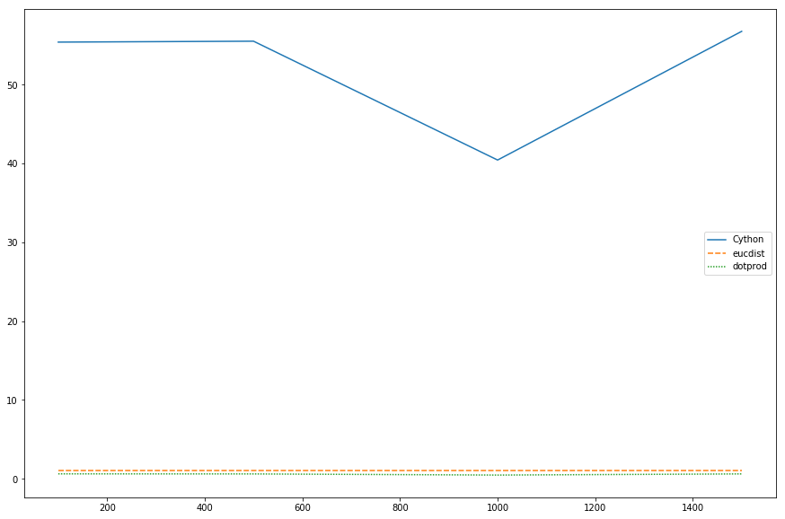

```python
import matplotlib.pyplot as plt
%matplotlib inline
import seaborn as sns
plt.figure(figsize=(15, 10))
sns.lineplot(data=time_rows)
plt.show()
```

Unsuprisingly Cython is doing much better. The trend does seemed to settle at a value as it does in R but this might be evident for more inputs. Overall R is performing better in almost all of the function they have in common. Here is look at the time the base python function eucdist takes

```python
base_time # times for [100, 500, 1000, 1500]
```

```
[3.045, 75.231, 315.346, 982.838]
```